# Basic R

#### Distributions and histograms

Let’s start by creating some normally distributed data, 1000 numbers with mean of 200 and a standard deviation of 40

```r
dat.norm <-rnorm(1000,200,40)
```

And some basic things we can do with that:

```r
l <-length(dat.norm) #how many points are there?
m <-mean (dat.norm) #mean of points generated
sd <-sd(dat.norm) #and the standard deviation
qu <-quantile(dat.norm,c(.025,.975))
l;m;sd;qu
```

```
## [1] 1000
```

```
## [1] 199.4555
```

```
## [1] 41.9996
```

```
##     2.5%    97.5%
## 118.0444 280.3759
```

And a couple of ways to plot - first with base R:

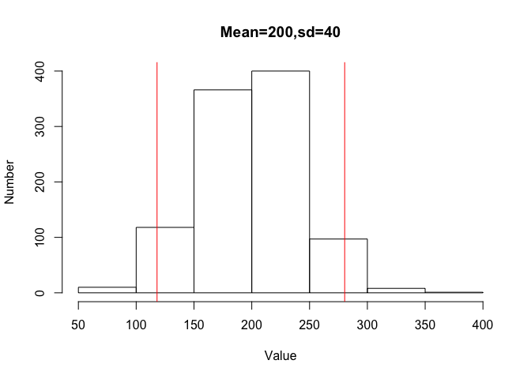

```r
hist(dat.norm,xlab="Value",ylab="Number",main="Mean=200,sd=40")
abline(v=qu,col="red")
```

This can be made prettier with the colhist function from TPG:

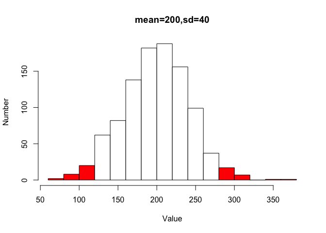

```r
colhist(dat.norm,labs=c("Value","Number","mean=200,sd=40"))
```

Notice the difference in the format for specifying axis labels and title.

#### Ending the session

When you are done and exit out of R studio, you will be asked if you want to save the workspace. If you do, then the next time you open the project, all of your files, variables, etc. will be restored. If you do not, your files will be opened, however you will need to rerun your code to generate objects, functions, etc.

### Conclusions

So at this point, you should have

1. Set up your project
2. Installed the latest version of TPG
3. Learned a bit about vectors, functions and plotting.

Our next step will be to look more closely at how real data are accessed, organized and manipulated in R. With that in place, we can then start exploring some real problems in population genetics.